# CKME 136 - Breast Cancer Diagnosis

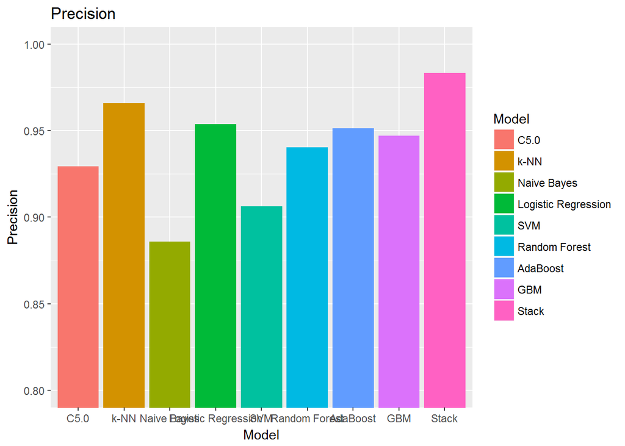

```r
ggplot(metrics2, aes(Model, Precision)) + geom_bar(stat="identity", aes(fill=Model)) + coord_cartesian(ylim=c(0.8,1)) + ggtitle("Precision")
```

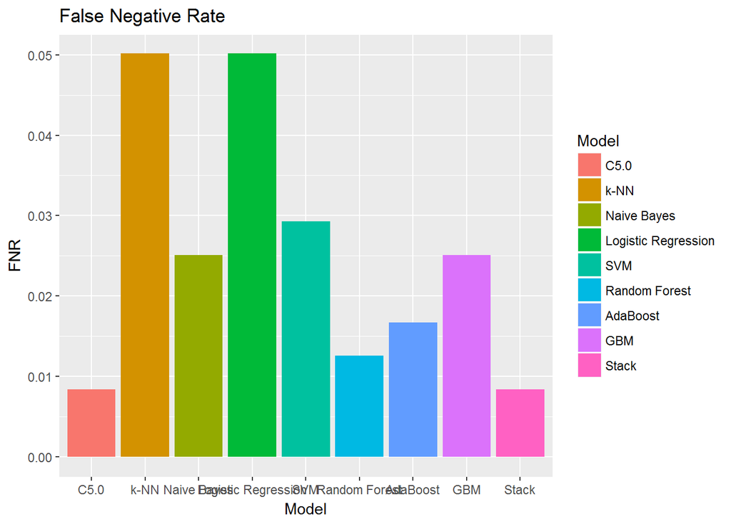

```r
ggplot(metrics2, aes(Model, FNR)) + geom_bar(stat="identity", aes(fill=Model)) + coord_cartesian(ylim=c(0,0.05)) + ggtitle("False Negative Rate")
```

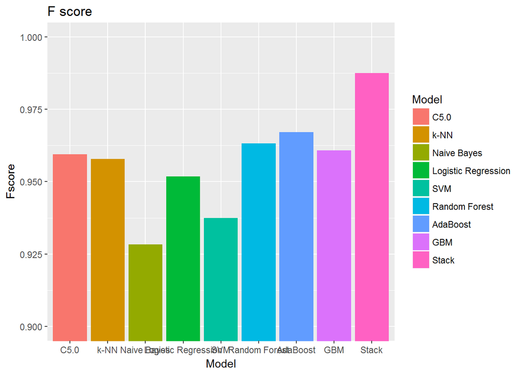

```r
ggplot(metrics2, aes(Model, Fscore)) + geom_bar(stat="identity", aes(fill=Model)) + coord_cartesian(ylim=c(0.9,1)) + ggtitle("F score")
```

# Conclusion

- Stacked model combining C5.0, k-NN, NB, Logistic regression, and SVM had highest reported performance metrics based on 5-fold CV.
- C5.0 Decision tree model performance equally well in terms of false negative rate (if we were to consider minimizing missed diagnoses).
- Given the extremely small sample size, issues of overfitting definitely exist.
  - Best way to counteract this would be to get more data, but healthcare domain isn’t the most publically available.
- In terms of usage and application to actual clinicians, a more user-friendly application could serve well
  - Perhaps a shiny app to run stacking model, if there was a possibility to automate calculations from tumor FNBs.